# Explaining gut content analyses (CGA) conducted on Scott Creek Lagoon fish diet samples

Drought-induced sympatry of two salmonid species: Feeding ecology and trophic niches of potential competitors

2025-12-01

# 1 Introduction

This document explains the analyses performed on juvenile salmonid diet (gut content) samples presented in the manuscript titled, “Drought-induced sympatry of two salmonid species: Feeding ecology and trophic niches of potential competitors”. A separate R markdown file explains the analyses conducted on natural abundance stable carbon and nitrogen isotope samples. Questions regarding these analyses or the R markdown should be directed to Dr. Joseph Kiernan at joseph.kiernan@noaa.gov.

- Minor Note: Some code chunks in this .Rmd file have been cached to help with document rendering (“knitting”) time. More info on caching can be found [here](https://bookdown.org/yihui/rmarkdown-cookbook/cache-path.html).

```r
# Load prey (gut content) data set  #332 obs, 26 vars

Data.Full <- read_csv("Lagoon_GCA_Input_Data/OUT.Consumed.csv")
```

## 1.1 Monthly summaries of fish processed for gut content analysis (Table S2 in manuscript)

```r
# Calculate summary statistics for each month separately
monthly_stats <- Data.Full %>%
  group_by(Month, Species) %>%
  dplyr::summarise(
    Count = n(),
    Mean_Length = mean(Fork.Length_mm, na.rm = TRUE),
    SD_Length = sd(Fork.Length_mm, na.rm = TRUE),
    .groups = "drop"
  )

# Calculate statistics for Overall (all months combined)
overall_stats <- Data.Full %>%
  group_by(Species) %>%
  dplyr::summarise(
    Count = n(),
    Mean_Length = mean(Fork.Length_mm, na.rm = TRUE),
    SD_Length = sd(Fork.Length_mm, na.rm = TRUE),
    .groups = "drop"
  ) %>%
  mutate(Month = "Overall") #Create a label for these rows

# Combine, order, and format
month_order <- c("Jun", "Jul", "Aug", "Sep", "Oct", "Nov", "Dec", "Overall")

final_fish_summary <- bind_rows(monthly_stats, overall_stats) %>%
# Convert Month to factor to force specific chronological order
  mutate(Month = factor(Month, levels = month_order)) %>%
  arrange(Month, Species) %>%
  select(Month, Species, Count, Mean_Length, SD_Length) #Ensure column order

final_fish_summary %>%
  kbl(
    caption = "Table S2 (partial). Monthly summaries of the number of stomach samples collected from lagoon-rearing juvenile coho salmon (Onki) and steelhead (Onmy)",
    col.names = c("Month", "Species", "Count", "Mean", "Std. Dev."),
    digits = c(0, 0, 0, 1, 1),
    format = "html"
  ) %>%
  kable_classic(font = "Cambria", full_width = FALSE) %>%
  add_header_above(c(" " = 3, "Fork length (mm)" = 2)) %>%
  collapse_rows(columns = 1, valign = "top")
```

Table S2 (partial). Monthly summaries of the number of stomach samples collected from lagoon-rearing juvenile coho salmon (Onki) and steelhead (Onmy)

| Month | Species | Count | Fork length (mm) Mean | Fork length (mm) Std. Dev. |
| --- | --- | --- | --- | --- |
| Jun | Onki | 34 | 145.4 | 8.9 |
|  | Onmy | 47 | 154.8 | 22.4 |
| Jul | Onki | 19 | 152.2 | 15.5 |
|  | Onmy | 30 | 178.8 | 37.3 |
| Aug | Onki | 4 | 162.5 | 9.5 |
|  | Onmy | 28 | 180.3 | 22.0 |
| Sep | Onki | 14 | 163.1 | 8.3 |
|  | Onmy | 28 | 169.0 | 37.8 |
| Oct | Onki | 14 | 159.9 | 14.0 |
|  | Onmy | 27 | 164.7 | 41.2 |
| Nov | Onki | 13 | 166.2 | 10.3 |
|  | Onmy | 28 | 186.8 | 44.6 |
| Dec | Onki | 7 | 177.3 | 6.8 |
|  | Onmy | 39 | 207.8 | 42.9 |
| Overall | Onki | 105 | 156.2 | 14.5 |
|  | Onmy | 227 | 177.1 | 39.5 |

## 1.2 Index of Relative Importance (IRI)

The package ‘DietR’ uses diet data to estimate trophic levels, electivity indices, and composite diet indices. We present the Index of Relative Importance (IRI) which relies on three variables: the number (N), mass (M), and frequency of occurrence (FO) of each diet prey category identified in the stomach contents of each sampled individual. More information about the package can be found [here.](https://cran.r-project.org/web/packages/dietr/vignettes/dietr-vignette.pdf)

IRI Workflow:

1. Calculate number (N%), frequency of occurrence (FO%), and biomass (M%): (1) by species and month and (2) by species for the whole study (overall). Format each data frame as input file for DietR.
2. Run DietR function to calculate IRI: (1) by species and month and (2) by species for the whole study (i.e., “Overall” - all sample periods [months] combined).
3. Save IRI output - Supplemental Table *S3* in the manuscript
4. Create Figure 1 in the manuscript - IRI Output by species for each month of the study and overall

### 1.2.1 Calculate IRI with the *DietR* package.

Utilizes the ‘CompositeIndices’ function within the *DietR* package. Note, other indices (in addition to IRI) can be calculated.

```r
# Read in IRI data sets
IRI.dat <- read.csv('Lagoon_GCA_Input_Data/IRI_input.csv', sep = ",", header = T)
IRI.study.dat <- read.csv('Lagoon_GCA_Input_Data/IRI_input_entirestudy.csv', sep = ",", header = T)

# Data wrangling
IRI.input <- IRI.dat %>%
  select(Predator, PreyCategory, PercentNumber, PercentOccurrence, PercentMass)

# Calculate and save monthly indices
IRI.monthly.output <- CompositeIndices(IRI.input,
  Indices = c("IRI"),
  PercentNumber = 3,
  PercentOccurrence = 4,
  PercentVolWeight = 5,
  ReturnRaw = TRUE,
  PercentOnly = TRUE
  )

# Create a new column containing the list names (the predator groupings)
IRI.monthly.df <- bind_rows(IRI.monthly.output, .id = "Group_ID")

# The next line will print raw list to screen (currently suppressed)
#print(IRI.monthly.output)
write.csv(IRI.monthly.df, "Lagoon_GCA_Results/IRI/IRI_Monthly_Output.csv", row.names = FALSE)

# Calculate and save entire study indices
IRI.study.output <- CompositeIndices(IRI.study.dat,
  Indices = c("IRI"),
  PercentNumber = 3,
  PercentOccurrence = 4,
  PercentVolWeight = 5,
  ReturnRaw = TRUE,
  PercentOnly = TRUE
  )

# Convert the list output to a single data frame
IRI.study.df <- bind_rows(IRI.study.output, .id = "Group_ID")

# The next line (currently suppressed) will print raw list to screen
#print(IRI.study.output)

write.csv(IRI.study.df, "Lagoon_GCA_Results/IRI/IRI_Study_Output.csv", row.names = FALSE)
```

### 1.2.2 Extract %IRI calculations and present values in a summary table

These data contribute to Figure 1 and also appear as Table S3 in the manuscript

```r
# Load libraries
library(tidyverse)
library(dietr)
library(knitr)
library(kableExtra)

# Reload data set
IRI.dat <- read.csv('Lagoon_GCA_Input_Data/IRI_input.csv', sep = ",", header = T)
IRI.study.dat <- read.csv('Lagoon_GCA_Input_Data/IRI_input_entirestudy.csv', sep = ",", header = T)

# Format input
IRI.input <- IRI.dat %>%
  select(Predator, PreyCategory, PercentNumber, PercentOccurrence, PercentMass)

# Run DietR Index of Relative Importance (IRI)
fresh_monthly_list <- CompositeIndices(IRI.input, Indices = "IRI", PercentNumber = 3,
                                       PercentOccurrence = 4, PercentVolWeight = 5,
                                       ReturnRaw = TRUE, PercentOnly = TRUE)

fresh_study_list <- CompositeIndices(IRI.study.dat, Indices = "IRI", PercentNumber = 3,
                                     PercentOccurrence = 4, PercentVolWeight = 5,
                                     ReturnRaw = TRUE, PercentOnly = TRUE)

# Convert and rename
df_monthly <- bind_rows(fresh_monthly_list, .id = "Group_ID")
df_study   <- bind_rows(fresh_study_list, .id = "Group_ID")

names(df_monthly)[2] <- "Prey"
names(df_monthly)[ncol(df_monthly)] <- "PercentIRI"
names(df_study)[2] <- "Prey"
names(df_study)[ncol(df_study)] <- "PercentIRI"

# Clean and combine
clean_monthly <- df_monthly %>%
  separate(Group_ID, into = c("Species", "Month"), sep = "[_.]", extra = "merge") %>%
  select(Species, Month, Prey, PercentIRI)

clean_study <- df_study %>%
  rename(Species = Group_ID) %>%
  mutate(Month = "Overall") %>%
  select(Species, Month, Prey, PercentIRI)

combined_data <- bind_rows(clean_monthly, clean_study)

# Format and pivot
final_table <- combined_data %>%
  mutate(IRI_Label = case_when(
    PercentIRI == 0 ~ "---",
    PercentIRI > 0 & PercentIRI < 0.1 ~ "<0.1",
    TRUE ~ sprintf("%.1f", PercentIRI)
  )) %>%
  select(Species, Prey, Month, IRI_Label) %>%
  pivot_wider(names_from = Month, values_from = IRI_Label, values_fill = "---") %>%
  arrange(Species, Prey) %>%
  select(Species, Prey, any_of(c("Jun", "Jul", "Aug", "Sep", "Oct", "Nov", "Dec", "Overall")))

# Set table geometry
n_total_cols <- ncol(final_table)
n_data_cols  <- n_total_cols - 2

# Left justify first 2 columns (Species, Prey), right justify all data columns
my_alignment <- c("l", "l", rep("r", n_data_cols))

# Generate table
knitr::kable(final_table,
             caption = "Table S3: Index of relative importance values (IRI, %) by month for each prey category identified in the stomachs of juvenile coho salmon (Onki) and steelhead (Onmy) ",
             col.names = c("Predator", "Prey taxon or category", names(final_table)[3:n_total_cols]),
             align = my_alignment) %>%
  kable_styling(
      bootstrap_options = c("striped", "hover"),
      full_width = FALSE,
      position = "left"
  ) %>%
  add_header_above(c(" " = 2, "Index of relative importance (%)" = n_data_cols)) %>%
  column_spec(3:n_total_cols, width = "1.5cm") %>%
  collapse_rows(columns = 1, valign = "top")
```

Table S3: Index of relative importance values (IRI, %) by month for each prey category identified in the stomachs of juvenile coho salmon (Onki) and steelhead (Onmy)

| Predator | Prey taxon or category | Index of relative importance (%) Jun | Index of relative importance (%) Jul | Index of relative importance (%) Aug | Index of relative importance (%) Sep | Index of relative importance (%) Oct | Index of relative importance (%) Nov | Index of relative importance (%) Dec | Index of relative importance (%) Overall |
| --- | --- | --- | --- | --- | --- | --- | --- | --- | --- |
| Onki | Actinopterygii | — | 0.8 | 12.8 | <0.1 | 1.2 | 0.9 | — | 0.2 |
|  | Amphipoda: Americorophium sp. | 24.4 | 21.7 | 23.1 | 41.3 | 24.3 | 47.8 | 71.0 | 48.5 |
|  | Amphipoda: Eogammarus sp. | 49.5 | 42.2 | 6.5 | 4.4 | 7.9 | 7.9 | 5.0 | 23.3 |
|  | Amphipoda: Megalorchestia | — | — | — | — | — | — | 1.7 | <0.1 |
|  | Amphipoda: undetermined | <0.1 | — | — | — | — | — | 1.0 | <0.1 |
|  | Decapoda: Emerita sp. | — | — | — | — | — | 4.2 | 9.3 | <0.1 |
|  | Decapoda: Megalopa | — | — | — | — | — | — | <0.1 | <0.1 |
|  | Diptera | 0.1 | <0.1 | — | — | <0.1 | <0.1 | 0.2 | <0.1 |
|  | Diptera: Chironomidae | <0.1 | 0.1 | <0.1 | 31.5 | 19.1 | 1.2 | — | 4.3 |
|  | Hemiptera: Corixidae | <0.1 | — | — | 0.5 | <0.1 | 1.6 | 0.2 | <0.1 |
|  | Isopoda: Cirolanidae | — | — | — | — | — | <0.1 | 11.4 | <0.1 |
|  | Isopoda: Gnorimosphaeroma sp. | 2.8 | 26.5 | 54.3 | 19.1 | 8.1 | 30.9 | 0.1 | 11.2 |
|  | Isopoda: undetermined | — | — | — | — | — | — | <0.1 | <0.1 |
|  | Mysidae: Neomysis mercedis | 17.8 | 5.3 | 3.3 | 1.0 | 0.2 | 0.8 | <0.1 | 5.5 |
|  | Other aquatics (non-insecta) | 0.2 | <0.1 | — | <0.1 | 0.2 | 0.4 | <0.1 | 0.2 |
|  | Other insects | 0.4 | <0.1 | — | <0.1 | 0.2 | — | — | 0.2 |
|  | Other terrestrials (Arachnida) | 0.2 | — | — | — | <0.1 | — | <0.1 | <0.1 |
|  | Terrestrial insects | 4.5 | 3.4 | — | 2.1 | 38.8 | 4.3 | <0.1 | 6.2 |
| Onmy | Actinopterygii | <0.1 | <0.1 | 0.6 | — | 0.2 | 0.2 | <0.1 | <0.1 |
|  | Amphipoda: Americorophium sp. | 3.1 | 6.5 | 17.3 | 12.2 | 21.6 | 12.3 | 54.9 | 22.3 |
|  | Amphipoda: Eogammarus sp. | 71.0 | 23.9 | 19.1 | 15.4 | 26.3 | 37.2 | 5.2 | 32.3 |
|  | Amphipoda: Megalorchestia | — | — | — | — | — | — | 23.7 | 0.6 |
|  | Amphipoda: undetermined | <0.1 | — | — | — | — | <0.1 | 0.7 | <0.1 |
|  | Decapoda: Emerita sp. | — | — | — | — | — | <0.1 | 2.4 | <0.1 |
|  | Diptera | <0.1 | <0.1 | <0.1 | — | — | — | 0.4 | <0.1 |
|  | Diptera: Chironomidae | — | <0.1 | <0.1 | 14.7 | 10.0 | 0.5 | 0.1 | 1.5 |
|  | Hemiptera: Corixidae | — | <0.1 | <0.1 | — | 0.1 | 1.9 | <0.1 | <0.1 |
|  | Isopoda: Cirolanidae | — | — | — | — | — | — | 1.7 | <0.1 |
|  | Isopoda: Gnorimosphaeroma sp. | 14.6 | 62.2 | 62.7 | 35.6 | 33.7 | 46.7 | 9.8 | 38.0 |
|  | Mysidae: Neomysis mercedis | 11.2 | 6.6 | 0.1 | 16.6 | 2.1 | 0.5 | <0.1 | 4.4 |
|  | Other aquatics (non-insecta) | <0.1 | 0.6 | <0.1 | 4.4 | 4.8 | 0.2 | 0.4 | 0.6 |
|  | Other insects | <0.1 | <0.1 | — | 0.8 | 1.1 | 0.3 | <0.1 | <0.1 |
|  | Other terrestrials (Arachnida) | <0.1 | — | — | — | <0.1 | <0.1 | <0.1 | <0.1 |
|  | Terrestrial insects | <0.1 | <0.1 | — | 0.2 | 0.1 | <0.1 | 0.6 | <0.1 |

### 1.2.3 Create table of “overall” IRI values, sorted from highest to lowest.

These data are used to check and verify the relative order that the prey categories are presented in Figure 1. They also contribute to Table S3 in the manuscript.

```r
# Load the taxa groupings to grab the codes
Prey.Codes <- read.csv("Lagoon_GCA_Input_Data/TaxaGroupings.csv") %>%
  select(PreyCategory, Code) %>%
  distinct()

# Filter for 'Overall', join the codes, sort from highest to lowest, and organize columns
overall_ranked_iri <- combined_data %>%
  filter(Month == "Overall") %>%
  select(Species, Prey, PercentIRI) %>%
  left_join(Prey.Codes, by = c("Prey" = "PreyCategory")) %>%
  select(Species, Prey, Code, PercentIRI) %>% # Places 'Code' right before the IRI values
  group_by(Species) %>%
  arrange(Species, desc(PercentIRI)) %>%
  ungroup()

# Export the cleanly ordered data to a CSV file
write.csv(overall_ranked_iri, "Lagoon_GCA_Results/IRI/Overall_Ranked_IRI_By_Species.csv", row.names = FALSE)

# Format the numbers for the display table with 3 decimal places
overall_ranked_iri %>%
  mutate(PercentIRI = case_when(
    PercentIRI == 0 ~ "---",
    TRUE ~ sprintf("%.3f%%", PercentIRI)
  )) %>%
  knitr::kable(
    caption = "Overall Study Niche Breadth: Prey categories ranked from highest to lowest Index of Relative Importance (%IRI).",
    col.names = c("Predator Species", "Prey Taxon / Category", "Code", "Overall IRI (%)"),
    align = "lllr"
  ) %>%
  kable_styling(
    bootstrap_options = c("striped", "hover", "condensed"),
    full_width = FALSE,
    position = "left"
  ) %>%
  collapse_rows(columns = 1, valign = "top")
```

Overall Study Niche Breadth: Prey categories ranked from highest to lowest Index of Relative Importance (%IRI).

| Predator Species | Prey Taxon / Category | Code | Overall IRI (%) |
| --- | --- | --- | --- |
| Onki | Amphipoda: Americorophium sp. | AME | 48.538% |
|  | Amphipoda: Eogammarus sp. | GAM | 23.261% |
|  | Isopoda: Gnorimosphaeroma sp. | GNO | 11.214% |
|  | Terrestrial insects | TER | 6.233% |
|  | Mysidae: Neomysis mercedis | NEO | 5.532% |
|  | Diptera: Chironomidae | CHI | 4.295% |
|  | Other aquatics (non-insecta) | OAN | 0.244% |
|  | Actinopterygii | FSH | 0.181% |
|  | Other insects | OIA | 0.154% |
|  | Hemiptera: Corixidae | COR | 0.100% |
|  | Decapoda: Emerita sp. | EME | 0.095% |
|  | Diptera | DIP | 0.076% |
|  | Other terrestrials (Arachnida) | SPD | 0.038% |
|  | Isopoda: Cirolanidae | CIR | 0.028% |
|  | Amphipoda: undetermined | AMP | 0.010% |
|  | Amphipoda: Megalorchestia | ORC | 0.001% |
|  | Decapoda: Megalopa | MEG | 0.000% |
|  | Isopoda: undetermined | ISO | 0.000% |
| Onmy | Isopoda: Gnorimosphaeroma sp. | GNO | 37.979% |
|  | Amphipoda: Eogammarus sp. | GAM | 32.335% |
|  | Amphipoda: Americorophium sp. | AME | 22.278% |
|  | Mysidae: Neomysis mercedis | NEO | 4.363% |
|  | Diptera: Chironomidae | CHI | 1.458% |
|  | Other aquatics (non-insecta) | OAN | 0.632% |
|  | Amphipoda: Megalorchestia | ORC | 0.600% |
|  | Other insects | OIA | 0.086% |
|  | Hemiptera: Corixidae | COR | 0.072% |
|  | Terrestrial insects | TER | 0.058% |
|  | Actinopterygii | FSH | 0.039% |
|  | Amphipoda: undetermined | AMP | 0.038% |
|  | Isopoda: Cirolanidae | CIR | 0.028% |
|  | Decapoda: Emerita sp. | EME | 0.018% |
|  | Diptera | DIP | 0.014% |
|  | Other terrestrials (Arachnida) | SPD | 0.002% |

## 1.3 Graphical contrasts of IRI values (Fig 1 in manuscript)

Goal: Create network plots using the *networkD3* package for the diets of juvenile Coho Salmon and Steelhead to illustrate Index of Relative Importance (%IRI) values. The initial plots display %IRI for each taxa group on the left side and monthly %IRI values on the right hand side.

Notes: * We are interested in showing the relationships of taxon groupings over time. The general plot formatting sums all of the values on the right side to create the node lengths on the left side of the plot. This formatting works if you are strictly looking at a value for the *entire study period*. If we used formatting the sankey plot would sum the values on the right (for each month) to create the width of the bars on the left (each taxon grouping) which isn’t what we want. Therefore, we need to scale the values on the left so they equal the “entire study value” on the right.

### 1.3.1 Dataset used for Fig. 1

1. The *DietR_Sankey_Coho.csv* data file is used to generate the coho plot. The values were copied form the IRI output file and reordered from greatest to lowest %IRI for the entire study. The column “Month2” is used to sort the data chronologically (after taxa groupings). Also, a Grouping column was added to distinguish %IRI > 1%. Note that %IRI values < 1% are grouped together as gray (at the bottom of the plot). (Used as the right hand side of the plot).
2. The *DietR_Sankey_Steelhead.csv* data file is used to generate the steelhead plot. The values were copied form the IRI output file and manipulated the same way as the coho file above.

### 1.3.2 Coho salmon plot

Half of Figure 1 (combined below).

```r
# Step 1: Read in coho monthly DietR output data
coho.dat <- read.csv('Lagoon_GCA_Input_Data/DietR_Sankey_Coho.csv', sep = ",", header = T) #77 obs, 9 var.

# Step 2: Bring in taxa groupings codes
DietCode.dat <- read.csv('Lagoon_GCA_Input_Data/TaxaGroupings.csv', sep = ",", header = T) #62 obs, 7 var.

DietCode1 <- DietCode.dat  %>%
   select(PreyCategory, Code) %>%   #62 obs of 2 var.
   distinct(PreyCategory, Code)     #18 obs of 2 var.

# Step 3: Set up df with Source and Taget information ("links")
coho <- coho.dat %>%
  left_join(., DietCode1) %>%
  mutate(Source = Code,
         Target = Month,
         Group = as.factor(Group))  #77 obs, 12 var.

# Check the df structure
str(coho)
```

```
## 'data.frame':    77 obs. of  12 variables:
##  $ Species          : chr  "Onki" "Onki" "Onki" "Onki" ...
##  $ PreyCategory     : chr  "Amphipoda: Americorophium sp." "Amphipoda: Americorophium sp." "Amphipoda: Americorophium sp." "Amphipoda: Americorophium sp." ...
##  $ Month            : chr  "Jun" "Jul" "Aug" "Sep" ...
##  $ Month2           : int  6 7 8 9 10 11 12 6 7 8 ...
##  $ PercentOccurrence: num  88.2 89.5 75 85.7 85.7 ...
##  $ PercentNumber    : num  29.2 26.7 33.1 40.5 25.3 ...
##  $ PercentMass      : num  13.65 9.72 8.31 38.16 17.67 ...
##  $ PercentIRI       : num  24.4 21.7 23.1 41.3 24.3 ...
##  $ Group            : Factor w/ 7 levels "1","2","3","4",..: 1 1 1 1 1 1 1 2 2 2 ...
##  $ Code             : chr  "AME" "AME" "AME" "AME" ...
##  $ Source           : chr  "AME" "AME" "AME" "AME" ...
##  $ Target           : chr  "Jun" "Jul" "Aug" "Sep" ...
```

```r
# Step 4: Adjust Percentage Monthly values so they add up to the entire study value.
#The sankey plot adds up all of the values on the right (for each month) to create the width of the bars on the left (each taxon/prey grouping).
# Therefore we want to scale the values on the left so they equal the "entire study value" on the right.

# Step 4.1 Read in entire study data
entirestudy.dat <- read.csv('Lagoon_GCA_Input_Data/DietR_IRI_Output_entirestudy.csv', sep = ",", header = T) #34 obs, 6 var.

# Step 4.2 Relabel columns for join
entirestudy <- entirestudy.dat %>%
  mutate(Study_PercentOccurrence = PercentOccurrence,  #relabeling to make the study values clear
         Study_PercentNumber = PercentNumber,
         Study_PercentMass = PercentMass,
         Study_PercentIRI = PercentIRI) %>%
  select(-PercentOccurrence, -PercentNumber, -PercentMass, -PercentIRI) #remove old named columns #34 obs of 6 var.

# Step 4.3 Join DietCodes to entire study df
entirestudy2 <- entirestudy %>%
  left_join(., DietCode1) #34 obs, 7 var.

# Coho only
coho.entirestudy <- entirestudy2 %>%
  filter(Species == "Onki") #18 obs of 7 var.

# Step 4.4 join codes to coho data
coho2 <- coho %>%
  left_join(., coho.entirestudy, by = "Code") %>% #77 obs of 15 var
  select(Species.x, Month, Month2, Code, Group, Source, Target, PercentOccurrence, PercentNumber, PercentMass, PercentIRI,
         Study_PercentOccurrence, Study_PercentNumber, Study_PercentMass, Study_PercentIRI) #reduce columns #77 obs of 15 var.

# Step 4.5 Calculate the sum of monthly values to help scale them relative to the entire study importance
sum.monthly <- coho %>%
  group_by(Code) %>%
  summarise(PercentOccurrence.total = sum(PercentOccurrence),
            PercentNumber.total = sum(PercentNumber),
            PercentMass.total = sum(PercentMass),
            PercentIRI.total = sum(PercentIRI))  #18 obs, 5 var.

# Step 4.6 Join monthly sums to coho data
coho3 <- coho2 %>%
  left_join(., sum.monthly) #77 obs of 19 var.

# Step 4.7 Scale monthly values to study values
coho.scaled <- coho3 %>%
  mutate(PercentOccurrence.scaled = (PercentOccurrence/PercentOccurrence.total)*Study_PercentOccurrence,
         PercentNumber.scaled = (PercentNumber/PercentNumber.total)*Study_PercentNumber,
         PercentMass.scaled = (PercentMass/PercentMass.total)*Study_PercentMass,
         PercentIRI.scaled = (PercentIRI/PercentIRI.total)*Study_PercentIRI) #Scaling each value by the entire study value
    #77 obs of 23 var.

# Step 5: Create nodes
nodes <- data.frame(
  name = c(as.character(coho.scaled$Source),
           as.character(coho.scaled$Target)) %>% unique()
)

# Step 6: Create source and target indexes (links?)
coho.scaled$IDsource <- match(coho.scaled$Source, nodes$name) -1
coho.scaled$IDtarget <- match(coho.scaled$Target, nodes$name) -1

# Step 7: Add a 'group' column to the nodes data frame:
# Note %IRI < 1% are grouped (10) and Months are grouped (11)
nodes$group <- as.factor(c("1", "2", "3", "4", "5", "6", "10", "10", "10", "10", "10", "10", "10", "10", "10", "10", "10", "10", "11", "11", "11", "11", "11", "11", "11"))

# Step 8: Assign a color for each group:
#Note %IRI < .2 are gray and Months are black.
# my_color <- 'd3.scaleOrdinal() .domain(["1", "2", "3", "4", "5", "6", "7", "8", "9", "10", "11", "12", "13", "14"])
#                                .range(["#8c510a", "#bf812d", "#dfc27d", "#f6e8c3", "#c7eae5", "#80cdc1", "#35978f", "#01665e", "gray",
#                                        "gray", "gray", "gray", "gray", "black"])'

my_color_co <- 'd3.scaleOrdinal() .domain(["1", "2", "3", "4", "5", "6", "10", "11"])
                               .range(["#00429D", "#6FA4A6", "#ABBF29", "#A7D3B4", "#6F812A", "#43749E", "gray", "black"])'

# Step 9: Set color for links to correspond with groups
coho.scaled$group <- coho.scaled$Group

# Step 10: Build the Sankey plot
coho.plot <- sankeyNetwork(Links = coho.scaled, Nodes = nodes,
                    Source = "IDsource", Target = "IDtarget",
                    Value = "PercentIRI.scaled", NodeID = "name",
                    NodeGroup = "group", LinkGroup = "group",
                    colourScale = my_color_co, iterations = 0,
                    nodeWidth = 5, nodePadding = 15,
                    sinksRight = F, fontSize = 12,
                    margin = list(left = 50, right = 0))

library(htmlwidgets)
coho.plot <- onRender(coho.plot,
  '
  function(el, x) {
    d3.selectAll(".node text")
      /* NEW FILTER: Targets only the starting nodes (zero incoming links) */
      .filter(function(d) { return d.targetLinks.length === 0; })
      .attr("x", -10)
      .attr("text-anchor", "end");
  }
  '
)

coho.plot
```

[interactive chart not shown]

```r
# Save html file:
# saveNetwork(coho.plot, "figures/Sankey/Coho_Sankey.html", selfcontained = T)

#If you want to have the hard html files you can save the plot using the code below.
# saveWidget(coho.plot, "figures/Sankey/Coho_Sankeywidget.html")
```

### 1.3.3 Steelhead Plot

Second (right) half of Figure 1 (combined below). Note some of the code is repeated form the Coho plot and has been commented out in this section.

```r
# Step 1: Read in steelhead monthly DietR output data
sh.dat <- read.csv('Lagoon_GCA_Input_Data/DietR_Sankey_Steelhead.csv', sep = ",", header = T)

# Step 2: Bring in taxa groupings codes
DietCode.dat <- read.csv('Lagoon_GCA_Input_Data/TaxaGroupings.csv', sep = ",", header = T)

DietCode1 <- DietCode.dat  %>%
  select(PreyCategory, Code) %>%
  distinct(PreyCategory, Code)

# Step 3: Set up df with Source and Target information
# REVERSED: Month is now the Source (Left), Code is the Target (Right)
steelhead <- sh.dat %>%
  left_join(., DietCode1) %>%
  mutate(Source = Month,
         Target = Code,
         Group = as.factor(Group))

# Steelhead only
sh.entirestudy <- entirestudy2 %>%
  filter(Species == "Onmy")

# Step 4.4 Join codes to steelhead data
steelhead2 <- steelhead %>%
  left_join(., sh.entirestudy, by = "Code") %>%
  select(Species.x, Month, Month2, Code, Group, Source, Target, PercentOccurrence, PercentNumber, PercentMass, PercentIRI,
         Study_PercentOccurrence, Study_PercentNumber, Study_PercentMass, Study_PercentIRI)

# Step 4.5 Calculate the sum of monthly values
sum.monthly.sh <- steelhead %>%
  group_by(Code) %>%
  summarise(PercentOccurrence.total = sum(PercentOccurrence),
            PercentNumber.total = sum(PercentNumber),
            PercentMass.total = sum(PercentMass),
            PercentIRI.total = sum(PercentIRI))

# Step 4.6 Join monthly sums to steelhead data
steelhead3 <- steelhead2 %>%
  left_join(., sum.monthly.sh)

# Step 4.7 Scale monthly values to study values
sh.scaled <- steelhead3 %>%
  mutate(PercentOccurrence.scaled = (PercentOccurrence/PercentOccurrence.total)*Study_PercentOccurrence,
         PercentNumber.scaled = (PercentNumber/PercentNumber.total)*Study_PercentNumber,
         PercentMass.scaled = (PercentMass/PercentMass.total)*Study_PercentMass,
         PercentIRI.scaled = (PercentIRI/PercentIRI.total)*Study_PercentIRI)

# Step 5: Create nodes
nodes <- data.frame(
  name = c(as.character(sh.scaled$Source),
           as.character(sh.scaled$Target)) %>% unique()
)

# Step 6: Create source and target indexes
sh.scaled$IDsource <- match(sh.scaled$Source, nodes$name) -1
sh.scaled$IDtarget <- match(sh.scaled$Target, nodes$name) -1

# Step 7: Dynamically extract the exact group assignments from the link data
# Since Target is the Taxa in this reversed plot, we map the node name to the Target's Group
node_groups <- sh.scaled %>%
  select(Target, Group) %>%
  distinct()

nodes <- nodes %>%
  left_join(node_groups, by = c("name" = "Target")) %>%
  # Assign group 11 to months, and use the exact inherited Group for the Taxa
  mutate(group = ifelse(name %in% c("Jun", "Jul", "Aug", "Sep", "Oct", "Nov", "Dec"),
                        "11", as.character(Group))) %>%
  mutate(group = as.factor(group))

# Blank out the month labels so they don't duplicate the Coho labels
nodes$name <- ifelse(nodes$group == "11", " ", as.character(nodes$name))

# Step 8: Unify the Steelhead color scale with the Coho color scale
# (Ensuring domain and range match perfectly)
my_color.sh <- 'd3.scaleOrdinal() .domain(["1", "2", "3", "4", "5", "6", "10", "11"])
                               .range(["#00429D", "#6FA4A6", "#ABBF29", "#A7D3B4", "#6F812A", "#43749E", "gray", "black"])'

# Step 9: Set color for links to correspond with groups
sh.scaled$group <- sh.scaled$Group

# Blank out the month labels so they don't duplicate the Coho labels in the final figure
nodes$name <- ifelse(nodes$group == "11", " ", as.character(nodes$name))

# Step 10: Build the Sankey plot!
sh.plot <- sankeyNetwork(Links = sh.scaled, Nodes = nodes,
                           Source = "IDsource", Target = "IDtarget",
                           Value = "PercentIRI.scaled", NodeID = "name",
                           NodeGroup = "group", LinkGroup = "group",
                           colourScale = my_color.sh, iterations = 0,
                           nodeWidth = 5, nodePadding = 15,
                           sinksRight = F, fontSize = 12,
                           margin = list(left = 0, right = 50)) # Push right margin for taxa labels

sh.plot
```

[interactive chart not shown]

```r
#saveNetwork(sh.plot, "figures/Sankey/Steelhead_Sankey.html", selfcontained = T)
#saveWidget(sh.plot, "figures/Sankey/Steelhead_Sankeywidget.html")
```

### 1.3.4 Figure 1 (Combined Plot)

Note: Final figure labeling was done manually outside of the R environment.

#Goal: to make a plot with coho on the left, SH on the right and month in the middle linking the two species plots

```r
# Format Coho Data (Taxa -> Month)
coho2 <- coho.scaled %>%
  mutate(Target_New = paste0(Month, "_CO")) %>%
  select(Species.x, Source = Code, Target = Target_New, PercentIRI.scaled)

# Format Steelhead Data (Month -> Taxa)
sh2 <- sh.scaled %>%
  mutate(Source_New = paste0(Month, "_SH"),
         Target_New = paste0(Code, "_SH_Taxa")) %>%
  select(Species.x, Source = Source_New, Target = Target_New, PercentIRI.scaled)

# Combine and assign clean color groupings
all <- bind_rows(coho2, sh2) %>%
  mutate(Group = case_when(
    grepl("^AME", Source) | grepl("^AME", Target) ~ "1",
    grepl("^GAM", Source) | grepl("^GAM", Target) ~ "2",
    grepl("^GNO", Source) | grepl("^GNO", Target) ~ "3",
    grepl("^TER", Source) | grepl("^TER", Target) ~ "4",
    grepl("^NEO", Source) | grepl("^NEO", Target) ~ "5",
    grepl("^CHI", Source) | grepl("^CHI", Target) ~ "6",
    grepl("^ORC|^EME|^MEG", Source) | grepl("^ORC|^EME|^MEG", Target) ~ "12",
    TRUE ~ "10"
  ) %>% as.factor())

# Create transparent dummy links to force the center gap between right and left halves
dummy_links <- data.frame(
  Species.x = "Dummy",
  Source = paste0(c("Jun", "Jul", "Aug", "Sep", "Oct", "Nov", "Dec"), "_CO"),
  Target = paste0(c("Jun", "Jul", "Aug", "Sep", "Oct", "Nov", "Dec"), "_SH"),
  PercentIRI.scaled = 0.0001,
  Group = as.factor("13")
)

all <- bind_rows(all, dummy_links)

# Explicitly define Node order to prevent stacking when iterations = 0
coho_taxa <- unique(coho2$Source)
coho_months <- paste0(c("Jun", "Jul", "Aug", "Sep", "Oct", "Nov", "Dec"), "_CO")
sh_months <- paste0(c("Jun", "Jul", "Aug", "Sep", "Oct", "Nov", "Dec"), "_SH")
sh_taxa <- unique(sh2$Target)

nodes <- data.frame(name = c(coho_taxa, coho_months, sh_months, sh_taxa))

# Assign Node color groups
nodes <- nodes %>%
  mutate(group = case_when(
    grepl("_CO$|_SH$", name) ~ "11", # Months
    grepl("^AME", name) ~ "1",
    grepl("^GAM", name) ~ "2",
    grepl("^GNO", name) ~ "3",
    grepl("^TER", name) ~ "4",
    grepl("^NEO", name) ~ "5",
    grepl("^CHI", name) ~ "6",
    grepl("^ORC|^EME|^MEG", name) ~ "12",
    TRUE ~ "10"
  ) %>% as.factor())

# Map the exact d3 Color Scale
my_color.all <- 'd3.scaleOrdinal() .domain(["1", "2", "3", "4", "5", "6", "10", "11", "12", "13"])
                               .range(["#00429D", "#6FA4A6", "#ABBF29", "#A7D3B4", "#6F812A", "#43749E", "gray", "black", "orange", "#00000000"])'

# Calculate indices and clean up display labels
all$IDsource <- match(all$Source, nodes$name) - 1
all$IDtarget <- match(all$Target, nodes$name) - 1

nodes$name <- gsub("_SH_Taxa", "", nodes$name) # Strip the steelhead suffix
nodes$name <- ifelse(grepl("_CO$|_SH$", nodes$name), " ", nodes$name) # Blank the months

# Build Plot
all.plot <- sankeyNetwork(Links = all, Nodes = nodes,
              Source = "IDsource", Target = "IDtarget",
              Value = "PercentIRI.scaled", NodeID = "name",
              NodeGroup = "group", LinkGroup = "Group",
              colourScale = my_color.all,
              iterations = 0, nodeWidth = 5, nodePadding = 10,
              sinksRight = F, fontSize = 12,
              margin = list(left = 50, right = 50))

# Inject JavaScript for margin labels
library(htmlwidgets)
all.plot <- onRender(all.plot,
  '
  function(el, x) {
    // Target Coho Taxa (Left)
    d3.selectAll(".node text")
      .filter(function(d) { return d.targetLinks.length === 0; })
      .attr("x", -10)
      .attr("text-anchor", "end");

    // Target Steelhead Taxa (Right)
    d3.selectAll(".node text")
      .filter(function(d) { return d.sourceLinks.length === 0; })
      .attr("x", 10)
      .attr("text-anchor", "start");
  }
  '
)

# Generate high resolution exports
# Due to the complexity of the plot, all labels will be manually manipulated outside of R
library(webshot2)
library(magick)

saveWidget(all.plot, "Lagoon_GCA_Results/Figures/Figure_1_temp.html", selfcontained = TRUE)

webshot(url = "Lagoon_GCA_Results/Figures/Figure_1_temp.html", file = "Lagoon_GCA_Results/Figures/Figure_1.pdf", delay = 0.5, zoom = 6)
```

[figure not shown]

```r
webshot(url = "Lagoon_GCA_Results/Figures/Figure_1_temp.html", file = "Lagoon_GCA_Results/Figures/Figure_1_temp.png", delay = 0.5, zoom = 6)
```

[figure not shown]

```r
img <- image_read("Lagoon_GCA_Results/Figures/Figure_1_temp.png")
image_write(img, format = "tiff", path = "Lagoon_GCA_Results/Figures/Figure_1.tif", density = "600x600", compression = "lzw")

unlink(c("Lagoon_GCA_Results/Figures/Figure_1_temp.html", "Lagoon_GCA_Results/Figures/Figure_1_temp.png"))
```

## 1.4 Schoener’s similarity index (D)

As a univariate measure of diet overlap, we calculated Schoener’s similarity index (D) for each salmonid species during each sample period using the *FSAmisc* package (Ogle 2022). Index values range from 0 to 1 and values ≥ 0.6 are typically considered substantial evidence of dietary overlap (Wallace Jr. 1981).

```r
# Re-load prey (gut content) data set
Data.Full <- read_csv("Lagoon_GCA_Input_Data/OUT.Consumed.csv")

# Define the seven individual months of the study to analyze
months_to_analyze <- c("Jun", "Jul", "Aug", "Sep", "Oct", "Nov", "Dec")

# Create function for the repeated (monthly) analyses
calculate_monthly_overlap <- function(month_abbr, full_data) {

  # Prepare output directory
  output_dir <- "Lagoon_GCA_Results/Schoener_Overlap"
  if (!dir.exists(output_dir)) dir.create(output_dir, recursive = TRUE)

  # Data manipulation and formatting
  month_guts1 <- subset(full_data, Month == month_abbr)
  month_guts2 <- month_guts1 %>% select(8:25)
  month_guts_percent <- tran(month_guts2, "percent")
  month_guts3 <- cbind(month_guts_percent, month_guts1[c("Species")])

  month_sum <- month_guts3 %>%
    group_by(Species) %>%
    dplyr::summarise(across(everything(), list(mean)))

  month_sum_format <- tryCatch({
    t(month_sum) %>% `colnames<-`(.[1, ]) %>% .[-1, ]
  }, error = function(e) { return(NULL) })

  if (is.null(month_sum_format)) return(NULL)

  month_df <- data.frame(month_sum_format, check.names = FALSE)
  month_df <- tibble::rownames_to_column(month_df, "Prey")

  if (!"Onki" %in% colnames(month_df) || !"Onmy" %in% colnames(month_df)) return(NULL)

  month_df$Onki <- as.numeric(month_df$Onki)
  month_df$Onmy <- as.numeric(month_df$Onmy)

  month_final_df <- month_df[rowSums(month_df[, c("Onki", "Onmy")]) > 0, ]

  if (nrow(month_final_df) == 0) return(NULL)

  # Perform calculations
  DO_calc <- dietOverlap(
    month_final_df$Onki,
    month_final_df$Onmy,
    prey = month_final_df$Prey,
    type = "Schoener"
  )

  # Capture and save output (suppressed from report)
  file_name <- file.path(output_dir, paste0("Schoener_", month_abbr, ".txt"))

  # Wrap the summary/print in brackets to ensure ALL printing side-effects are caught
  captured_text <- capture.output({
    print(summary(DO_calc, verbose = TRUE, digits = 2))
  })

  # Write to file
  writeLines(captured_text, file_name)

  # Print confirmation (Visible in Report)
  cat(paste("Saved output for", month_abbr, "to", file_name, "\n"))

  #Return invisible to prevent auto-printing the object
  invisible(DO_calc)
}
```

### 1.4.1 Calculating Schoener’s D (diet overlap index) for each individual sample month

Details for each monthly contrast will be saved to the local directory with the file path (“Lagoon_GCA_Results/Schoener_Overlap”)

```r
# lapply() applies the new function to every item in the 'months_to_analyze' list.
all_results <- lapply(months_to_analyze,
                      FUN = calculate_monthly_overlap,
                      full_data = Data.Full)
```

```
## The Schoener diet overlap index is 0.58.
```

```
## The following observed proportional diets were used:
```

```
## Saved output for Jun to Lagoon_GCA_Results/Schoener_Overlap/Schoener_Jun.txt
```

```
## The Schoener diet overlap index is 0.62.
##
## The following observed proportional diets were used:
```

```
## Saved output for Jul to Lagoon_GCA_Results/Schoener_Overlap/Schoener_Jul.txt
```

```
## The Schoener diet overlap index is 0.75.
##
## The following observed proportional diets were used:
```

```
## Saved output for Aug to Lagoon_GCA_Results/Schoener_Overlap/Schoener_Aug.txt
```

```
## The Schoener diet overlap index is 0.55.
##
## The following observed proportional diets were used:
```

```
## Saved output for Sep to Lagoon_GCA_Results/Schoener_Overlap/Schoener_Sep.txt
```

```
## The Schoener diet overlap index is 0.52.
##
## The following observed proportional diets were used:
```

```
## Saved output for Oct to Lagoon_GCA_Results/Schoener_Overlap/Schoener_Oct.txt
```

```
## The Schoener diet overlap index is 0.49.
##
## The following observed proportional diets were used:
```

```
## Saved output for Nov to Lagoon_GCA_Results/Schoener_Overlap/Schoener_Nov.txt
```

```
## The Schoener diet overlap index is 0.7.
##
## The following observed proportional diets were used:
```

```
## Saved output for Dec to Lagoon_GCA_Results/Schoener_Overlap/Schoener_Dec.txt
```

```r
# Name the list elements with the month abbreviations
names(all_results) <- months_to_analyze

# Accessing the results
# Note: we can access any individual month's full result:
#print(all_results$Jun)

# Or access a summary for just one specific month of interest (e.g., Sep):
# summary(all_results$Sep, verbose = TRUE, digits = 2)
```

```r
schoener_values <- sapply(all_results, function(result) {
  if (is.null(result)) {
    return(NA)
  } else {
    return(result$doi)
  }
})

# Create the final data frame
overlap_summary_table <- data.frame(
  Month = names(schoener_values),
  Schoener_D = schoener_values,
  row.names = NULL #Clean up row names
)

write_csv(overlap_summary_table, "Lagoon_GCA_Results/Schoener_Overlap/monthly_diet_overlap_summary.csv")
```

Calculating the overall Schoener’s D (all monthly data pooled)

```r
# The following code calculates the overall (i.e., study-wide) Schoener's D value

Overall.Guts2 <- Data.Full %>% select(8:25)
Overall.Guts.percent <- tran(Overall.Guts2, "percent")
Overall.Guts3 <- cbind(Overall.Guts.percent, Data.Full[c("Species")])

Overall.Sum <- Overall.Guts3 %>% group_by(Species) %>% dplyr::summarise(across(everything(), list(mean)))

Overall.Sum.Format <- t(Overall.Sum) %>% `colnames<-`(.[1, ]) %>% .[-1, ]
Overall.df <- data.frame(Overall.Sum.Format)
Overall.df <- tibble::rownames_to_column(Overall.df, "Prey")

Overall.df$Onki <- as.numeric(Overall.df$Onki)
Overall.df$Onmy <- as.numeric(Overall.df$Onmy)

Overall.Final.df <- Overall.df[rowSums(Overall.df[2:3])>0,]

DO.Overall <- dietOverlap(Overall.Final.df$Onki, Overall.Final.df$Onmy, prey=Overall.Final.df$Prey, type= "Schoener")

# Capture and save output
output_dir <- "Lagoon_GCA_Results/Schoener_Overlap"
if (!dir.exists(output_dir)) dir.create(output_dir, recursive = TRUE)

file_name <- file.path(output_dir, "Schoener_Overall.txt")

# Wrap the summary/print in brackets to ensure ALL printing side-effects are caught
captured_text <- capture.output({
    print(summary(DO.Overall, verbose = TRUE, digits = 2))
})
```

```
## The Schoener diet overlap index is 0.69.
```

```
## The following observed proportional diets were used:
```

```r
writeLines(captured_text, file_name)

# Print confirmation
cat(paste("Saved Overall output to", file_name, "\n"))
```

```
## Saved Overall output to Lagoon_GCA_Results/Schoener_Overlap/Schoener_Overall.txt
```

```r
# Extract the "overall" (study-wide) Schoener's D value for the table
Overall_Schoener_D <- DO.Overall$doi
```

### 1.4.2 Summary table of Schoener’s D values

These data contribute, in part, to Table 3 in the manuscript

```r
# Create a data frame for the overall result
overall_row <- data.frame(
  Month = "Overall",
  Schoener_D = Overall_Schoener_D
)

# Bind the monthly and overall results
final_overlap_table <- rbind(overlap_summary_table, overall_row)

# Create summary table
final_overlap_table %>%
  knitr::kable(
    caption = "Table 3 (in part) Schoener's diet overlap (D) between coho salmon and steelhead",
    col.names = c("Month", "Schoener's D"), #Rename columns
    digits = 2,
    format = "html"
  ) %>%
  kable_classic(font = "Cambria", full_width = FALSE)
```

Table 3 (in part) Schoener’s diet overlap (D) between coho salmon and steelhead

| Month | Schoener’s D |
| --- | --- |
| Jun | 0.58 |
| Jul | 0.62 |
| Aug | 0.75 |
| Sep | 0.55 |
| Oct | 0.52 |
| Nov | 0.49 |
| Dec | 0.70 |
| Overall | 0.69 |

## 1.5 Additional analyses of gut content data

```r
rm(list=ls()) #clear environment

#Load packages
library(ggplot2)
library(vegan)
library(readr)
library(dplyr)
library(tidyverse)
library(ggrepel)
library(patchwork)
library(knitr)
library(kableExtra)
library(grid)

# Load data set
Fish.Guts.All.Prey <- read_csv("Lagoon_GCA_Input_Data/OUT.Consumed.csv")

# Define the months to analyze
months_to_analyze <- c("Jun", "Jul", "Aug", "Sep", "Oct", "Nov", "Dec")

# Create a function for the repeated analysis
run_monthly_indval <- function(month_abbr, full_data) {

# Subset data for the month of interest
  month_data <- full_data[which(full_data$Month == month_abbr), ]

# Add a QC check to ensure all months have data
  if (nrow(month_data) == 0) {
    message("No data found for this month. Skipping.")
    return(NULL) #Return NULL to skip this month
  }

# Extract only diet items
  month_guts_only <- month_data[8:25]
 }
```

## 1.6 Indicator species analysis

We used the indicator value (IndVal) method developed by Dufrêne and Legendre (1997) to identify the prey categories strongly associated with the diets of each salmonid species during each month of the study. An IndVal varies from 0–1 and attains its maximum value when a prey category is restricted to the diets of one group exclusively and occurs in the stomachs of all individuals of that group.

```r
# Load packages for this specific analysis
library(indicspecies)
library(permute)
library(dplyr)
library(readr)

# Load data set
Fish.Guts.All.Prey <- read_csv("Lagoon_GCA_Input_Data/OUT.Consumed.csv")

# Define the months to analyze
months_to_analyze <- c("Jun", "Jul", "Aug", "Sep", "Oct", "Nov", "Dec")

# Create a Function for the Repeated Analysis
run_monthly_indval <- function(month_abbr, full_data) {

  # Subset data for the month of interest
  month_data <- full_data[which(full_data$Month == month_abbr), ]

  # Add a check to ensure all months have data
  if (nrow(month_data) == 0) {
    message("No data found for this month. Skipping.")
    return(NULL) #Return NULL to skip this month
  }

  # Extract only diet items
  month_guts_only <- month_data[8:25]

## Run Indicator Species Analysis
  # Set seed for reproducibility
  set.seed(123)

  indic_raw <- multipatt(month_guts_only,
                        month_data$Species,
                        func = "IndVal.g",
                        duleg = TRUE,
                        control = how(nperm = 9999))

  # Return the result object
  return(indic_raw)
}

# Run the analysis for all (seven) months of the study
all_indval_results <- lapply(months_to_analyze,
                             FUN = run_monthly_indval,
                             full_data = Fish.Guts.All.Prey)

# Name the list elements with the month abbreviations
names(all_indval_results) <- months_to_analyze
```

### 1.6.1 Extract significant IndVal results and create a summary table

These results appear in Table 2 of the manuscript

```r
library(knitr)
library(tidyr)
library(tibble)
library(kableExtra)

# Define the month abbreviations in chronological order
months_to_analyze <- names(all_indval_results)

# Initialize an empty list to store the formatted monthly results
formatted_results_list <- list()

for (month_abbr in months_to_analyze) {
  result <- all_indval_results[[month_abbr]]

  # Skip if the result is NULL
  if (is.null(result)) {
    next
  }

  # Extract the significance table
  sign_df <- result$sign %>%
    rownames_to_column(var = "Prey_Item") %>%
    as_tibble()

  # Extract A and B values
  lookup_coords <- cbind(seq_len(nrow(sign_df)), sign_df$index)

  # Extract the values as vectors
  A_values_vector <- result$A[lookup_coords]
  B_values_vector <- result$B[lookup_coords]

  # Create temporary data frame
  AB_df <- data.frame(
    Prey_Item = sign_df$Prey_Item,
    A_stat = A_values_vector,
    B_stat = B_values_vector,
    stringsAsFactors = FALSE
  ) %>%
    as_tibble()

  # Join the significance table with the A and B values
  full_month_df <- sign_df %>%
    left_join(AB_df, by = "Prey_Item") %>%
    mutate(
      Month = month_abbr,
      # Convert the pattern index back to the predator name (Onki or Onmy)
      Predator = colnames(result$comb)[index]
      ) %>%
    select(Month, Predator, Prey_Item, A_stat, B_stat, stat, p.value)

  # Filter for significance (p.value <= 0.05)
  significant_indicators <- full_month_df %>%
    filter(p.value <= 0.05)

  # Store the significant results for this month
  formatted_results_list[[month_abbr]] <- significant_indicators
}

# Combine and sort the results
final_indicators_table <- bind_rows(formatted_results_list) %>%
  # Convert Month to a factor so it sorts by time (Jun, Jul...)
  mutate(Month = factor(Month, levels = months_to_analyze)) %>%
  # Sort: 1) Month, 2) Predator (Onki < Onmy), 3) P-value (Lowest to Highest)
  arrange(Month, Predator, p.value)

# Format the final table
final_indicators_table %>%
  mutate(
    # Optional: Clean up Predator names for display if desired
    # Predator = ifelse(Predator == "Onki", "Coho", "Steelhead")
  ) %>%
  knitr::kable(
    caption = "Table 2. Diet indicator values (IndVal) by month, derived from the stomach contents of lagoon-rearing juvenile coho salmon and steelhead",
    col.names = c("Month", "Predator", "Prey category", "A", "B", "IndVal", "p-Value"),
    # Digits: A, B, Stat = 2 decimals; P-value = 3 decimals
    digits = c(0, 0, 0, 2, 2, 2, 3),
    format = "html"
  ) %>%
  kable_classic(font = "Cambria", full_width = FALSE) %>%
  collapse_rows(columns = 1:2, valign = "top")
```

Table 2. Diet indicator values (IndVal) by month, derived from the stomach contents of lagoon-rearing juvenile coho salmon and steelhead

| Month | Predator | Prey category | A | B | IndVal | p-Value |
| --- | --- | --- | --- | --- | --- | --- |
| Jun | Onki | Amphipoda: Americorophium sp. | 0.83 | 0.88 | 0.86 | 0.000 |
|  |  | Terrestrial insects | 0.96 | 0.47 | 0.67 | 0.000 |
|  |  | Other insects | 0.98 | 0.21 | 0.45 | 0.007 |
|  |  | Other terrestrials (Arachnida) | 0.95 | 0.18 | 0.41 | 0.011 |
|  |  | Diptera | 0.92 | 0.18 | 0.40 | 0.018 |
|  | Onmy | Amphipoda: Eogammarus sp. | 0.73 | 1.00 | 0.85 | 0.000 |
|  |  | Isopoda: Gnorimosphaeroma sp. | 0.83 | 0.72 | 0.77 | 0.001 |
| Jul | Onki | Terrestrial insects | 0.99 | 0.26 | 0.51 | 0.013 |
|  | Onmy | Isopoda: Gnorimosphaeroma sp. | 0.80 | 0.97 | 0.88 | 0.000 |
| Sep | Onki | Terrestrial insects | 0.80 | 0.50 | 0.63 | 0.011 |
|  |  | Hemiptera: Corixidae | 1.00 | 0.21 | 0.46 | 0.032 |
|  | Onmy | Mysidae: Neomysis mercedis | 0.97 | 0.68 | 0.81 | 0.002 |
|  |  | Other aquatics (non-insecta) | 0.95 | 0.61 | 0.76 | 0.005 |
|  |  | Isopoda: Gnorimosphaeroma sp. | 0.81 | 0.89 | 0.85 | 0.022 |
| Oct | Onki | Terrestrial insects | 0.95 | 0.86 | 0.90 | 0.000 |
|  | Onmy | Isopoda: Gnorimosphaeroma sp. | 0.85 | 0.85 | 0.85 | 0.003 |
|  |  | Amphipoda: Eogammarus sp. | 0.86 | 0.74 | 0.80 | 0.027 |
| Nov | Onki | Terrestrial insects | 0.80 | 0.77 | 0.78 | 0.000 |
|  |  | Amphipoda: Americorophium sp. | 0.78 | 1.00 | 0.88 | 0.002 |
|  |  | Decapoda: Emerita sp. | 0.91 | 0.46 | 0.65 | 0.006 |
|  | Onmy | Amphipoda: Eogammarus sp. | 0.87 | 0.96 | 0.92 | 0.000 |
|  |  | Isopoda: Gnorimosphaeroma sp. | 0.76 | 1.00 | 0.87 | 0.025 |
| Dec | Onki | Isopoda: Cirolanidae | 0.90 | 0.86 | 0.88 | 0.001 |
|  |  | Decapoda: Emerita sp. | 0.72 | 1.00 | 0.85 | 0.002 |
|  | Onmy | Isopoda: Gnorimosphaeroma sp. | 0.96 | 0.82 | 0.89 | 0.002 |
|  |  | Amphipoda: Megalorchestia | 0.89 | 0.82 | 0.85 | 0.023 |

## 1.7 Nonmetric multidimensional scaling (NMDS) & Analysis of Similarities (ANOSIM)

Nonmetric multidimensional scaling (NMDS) ordinations were used to explore patterns of variation among the stomach contents of individual lagoon-captured coho salmon and steelhead. We assessed the contribution and significance of each prey category to the NMDS ordination using the ‘envfit’ function in ‘vegan’, applying 999 permutations and a significance threshold of *p* ≤ 0.01.

To test whether the dietary composition of individual fish differed between coho salmon and steelhead, we employed one-way analysis of similarities (ANOSIM; Clarke 1993) on the same Bray-Curtis matrix used for NMDS ordinations. ANOSIM generates a test statistic (R) scaled between −1 and 1 to describe group (species) differences based on ranked dissimilarities. Positive R-values indicate greater dietary dissimilarity between groups than within each group, whereas an R-value of 0 indicates little or no dietary separation between groups and negative R-values indicate greater dietary dissimilarity within each group than between them (Clarke and Gorley 2001). The statistical significance of the R-statistic was determined with 999 random permutations.

```r
rm(list=ls()) #clear environment

#Load packages
library(ggplot2)
library(vegan)
library(readr)
library(dplyr)
library(tidyverse)
library(ggrepel)
library(patchwork)
library(knitr)
library(kableExtra)
```

# 2 NMDS data loading and pre-processing

```r
# Read in the main data (expect 332 rows, 26 columns)
Fish.Guts.All.Prey <- read_csv("Lagoon_GCA_Input_Data/OUT.Consumed.csv")

# Read in the groupings/codes
#this reduces clutter in the NMDS ordinations
Prey.Codes <- read_csv("Lagoon_GCA_Input_Data/TaxaGroupings.csv")

# Identify prey columns
prey_cols_indices <- 8:25

# Create a clean version of the full dataset with renamed columns
Fish.Guts.Clean <- Fish.Guts.All.Prey %>%
  rename_at(
    vars(names(.)[prey_cols_indices]),
    ~ as.vector(na.omit(Prey.Codes$Code[match(., Prey.Codes$PreyCategory)]))
  )
# The next line checks successful conversion of taxa names to taxa codes (currently suppressed)
# Fish.Guts.Clean
```

Defining the NMDS function and analysis parameters

```r
analyze_diet <- function(data, subset_name, prey_indices) {

  # Subset the specific prey matrix
  guts_matrix <- data[, prey_indices]

  # Standardization and transformation of matrix
  guts_rel <- decostand(guts_matrix, method = "total")
  guts_arcsine <- asin(sign(guts_rel) * sqrt(abs(guts_rel)))

  #### Run NMDS ###
  set.seed(2112)
  nmds_res <- metaMDS(comm = guts_arcsine, distance = "bray",
                      trace = FALSE, autotransform = FALSE,
                      k = 2, trymax = 1000, wascores = TRUE)#

  # Envfit (Vectors)
  ef_res <- envfit(nmds_res, guts_matrix, permutations = 999)

  spp_scrs <- as.data.frame(scores(ef_res, display = "vectors"))
  spp_scrs$Species <- rownames(spp_scrs)
  spp_scrs$pval <- ef_res$vectors$pvals
  sig_spp_scrs <- subset(spp_scrs, pval <= 0.01)

  # Format string for table (prey in alphabetized order)
  sorted_species <- sort(sig_spp_scrs$Species)
  sig_list_str <- paste(sorted_species, collapse = ", ")

  if(sig_list_str == "") sig_list_str <- "None"

  #### Run ANOSIM analysis ###
  anosim_res <- anosim(guts_arcsine, data$Species, permutations = 999, distance = "bray")

  # Plotting data
  plot_df <- data.frame(
    NMDS1 = nmds_res$points[,1],
    NMDS2 = nmds_res$points[,2],
    Species = data$Species
  )

  # Create ggplot
  p <- ggplot(plot_df, aes(x = NMDS1, y = NMDS2, col = Species)) +
    geom_point() +
    stat_ellipse(aes(fill = Species), geom = "polygon", alpha = 0.25, level = 0.95) +
    scale_color_manual(values = c("Onki" = "#D55E00", "Onmy" = "#0072B2")) +
    scale_fill_manual(values = c("Onki" = "#D55E00", "Onmy" = "#0072B2")) +
    theme_classic() +
    theme(
      legend.position = "none",
      panel.grid = element_blank(),
      axis.text = element_blank(),
      axis.ticks = element_blank(),
      axis.title = element_blank(),
      plot.title = element_text(family = "serif"),
      text = element_text(family = "serif")
    ) +
    labs(title = subset_name)

  # Add vectors if significant
  if(nrow(sig_spp_scrs) > 0) {
    p <- p +
      geom_segment(data = sig_spp_scrs,
                   aes(x = 0, xend = NMDS1, y = 0, yend = NMDS2),
                   arrow = arrow(length = unit(0.20, "cm")),
                   colour = "grey0", lwd = 0.3, inherit.aes = FALSE) +
      geom_text_repel(data = sig_spp_scrs,
                      aes(x = NMDS1, y = NMDS2, label = Species),
                      colour = "grey0", cex = 3, direction = "both",
                      segment.size = 0.25, inherit.aes = FALSE,
                      family = "serif",
                      max.overlaps = Inf)
  }

  return(list(
    period = subset_name,
    stress = nmds_res$stress,
    anosim_r = anosim_res$statistic,
    anosim_p = anosim_res$signif,
    sig_species = sig_list_str,
    plot = p
  ))
}
```

### 2.0.1 Run NMDS analysis loop

Note: This chunk of code is slow to run as it loops through all time periods (months + overall)

```r
#Define the periods in specific order
periods <- c("Jun", "Jul", "Aug", "Sep", "Oct", "Nov", "Dec", "Overall")

# IMPORTANT: Initialize the empty list before starting the loop
results_list <- list()

for(per in periods) {

  #Filter data
  if(per == "Overall") {
    curr_data <- Fish.Guts.Clean
  } else {
    curr_data <- Fish.Guts.Clean %>% filter(Month == per)
  }

  # Run the function defined above
  # Wrap in suppressWarnings to keep the output clean
  suppressWarnings({
    results_list[[per]] <- analyze_diet(curr_data, per, prey_cols_indices)
  })
}
```

### 2.0.2 Summary table of NMDS and ANOSIM results

The results summarized in this chunk are used, in part, to populate Table 3 in the manuscript

```r
# Compile stats into a data frame with specific column order
summary_df <- map_dfr(results_list, ~ data.frame(
  Period = .x$period,
  ANOSIM_R = round(.x$anosim_r, 3),
  ANOSIM_P = round(.x$anosim_p, 3),
  Stress = round(.x$stress, 2),
  Significant_Prey = .x$sig_species
))

# Create summary table
kbl(summary_df,
    col.names = c("Month", "R-stat", "p-value", "2-D stress", "Significant prey"),
    caption = "<span style='font-family:Cambria;'>Summary of NMDS final stress values and ANOSIM results by sample period</span>",
    escape = FALSE) %>%
  kable_styling(bootstrap_options = c("striped", "hover", "condensed"),
                full_width = FALSE,
                html_font = "Cambria") %>%
  add_header_above(c(" " = 1, "ANOSIM" = 2, "NMDS" = 2))
```

Summary of NMDS final stress values and ANOSIM results by sample period

| Month | ANOSIM R-stat | ANOSIM p-value | NMDS 2-D stress | NMDS Significant prey |
| --- | --- | --- | --- | --- |
| Jun | 0.327 | 0.001 | 0.19 | AME, CHI, GAM, GNO, NEO, SPD |
| Jul | 0.228 | 0.001 | 0.17 | GNO, NEO, TER |
| Aug | 0.254 | 0.102 | 0.11 | AME |
| Sep | 0.147 | 0.018 | 0.18 | AME, CHI, GAM, GNO, NEO |
| Oct | 0.231 | 0.003 | 0.16 | GNO |
| Nov | 0.562 | 0.001 | 0.15 | AME, GAM, GNO, OAN, TER |
| Dec | -0.078 | 0.690 | 0.11 | AME, AMP, EME, ORC |
| Overall | 0.107 | 0.001 | 0.20 | AME, CHI, CIR, DIP, EME, GAM, GNO, NEO, ORC |

### 2.0.3 Create and assemble NMDS plots

```r
# Define standardized labels for all plots
# This maps the internal data code (Jun) to journal preferred format ((a) Jun)
plot_labels <- c(
  "Jun" = "(a) Jun",
  "Jul" = "(b) Jul",
  "Aug" = "(c) Aug",
  "Sep" = "(d) Sep",
  "Oct" = "(e) Oct",
  "Nov" = "(f) Nov",
  "Dec" = "(g) Dec",
  "Overall" = "(h) Overall"
)
```

### 2.0.4 Generate multi-panel NMDS Ordination plots (Figure S1)

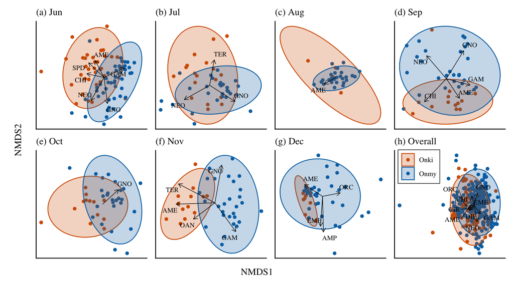

Figure S1. Ordination plots (NMDS) of the stomach contents of juvenile coho salmon (*Oncorhynchus kisutch*; Onki) and steelhead (*O. mykiss*; Onmy) captured in the Scott Creek lagoon during each month of the study (Jun–Dec, panels a–g, respectively). Panel h shows composited data from all months of the study. Points are individual samples and ellipses represent the 95% confidence interval around the centroid of each fish species in ordination space. Vectors illustrate prey categories with significant (*p*< 0.01) loadings on NMDS axes 1 and 2, and prey category codes are defined in Table 1 of the main document. Each panel is an independent ordination and the unitless axes are arbitrary and unique to each time period.

Figure note: The published figure may differ from the one produced above as we manually manipulated the position of some invertebrate prey category labels to reduce clutter and improve clarity.